# Math 32: Exploration 3

# Normal Distribution

5. Make adjustments to the code below to repeat what was done above with the uniform distribution, but this time looking at the normal distribution (hint: use the `rnorm` command).

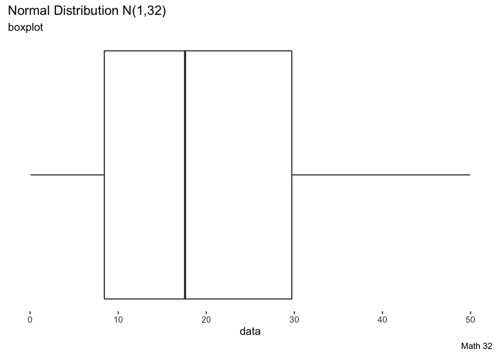

```r
N <- 1000
a <- 1
b <- 32
data <- rnorm(N, a, b)
df <- data.frame(data)

ggplot(df, aes(y = data)) +
  coord_flip() +
  geom_boxplot() +
  labs(title = paste0("Normal Distribution N(", a, ",", b, ")"),
       subtitle = "boxplot",
       caption = "Math 32") +
  theme(axis.text.y = element_blank(),
        axis.ticks.y = element_blank(),
        panel.background = element_blank(),
        panel.grid.major = element_blank(),
        panel.grid.minor = element_blank()) +
  ylim(0,50)
```

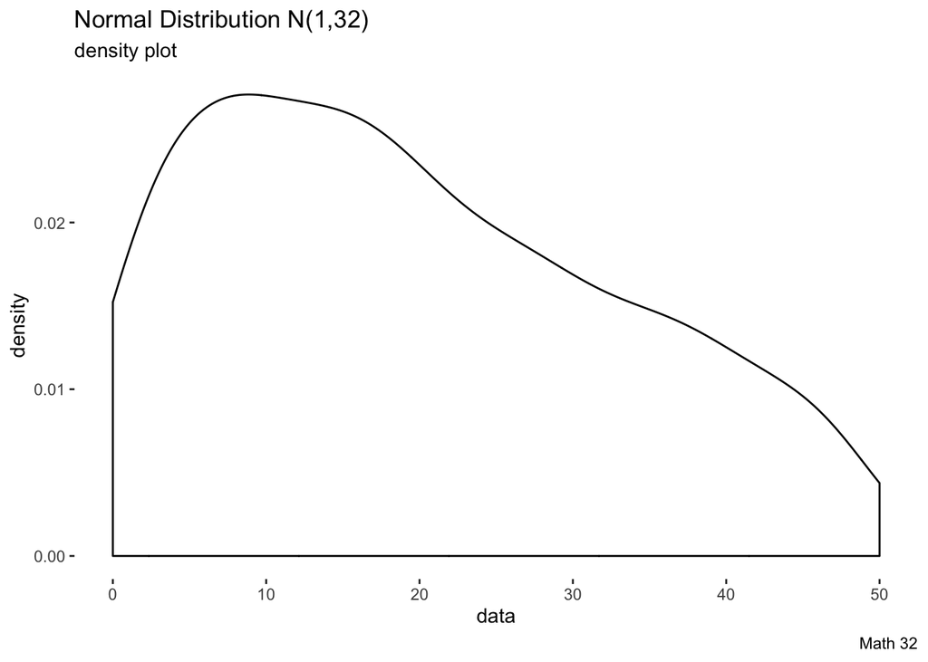

```r
ggplot(df, aes(x = data)) +
  geom_density() +
  labs(title = paste0("Normal Distribution N(", a, ",", b, ")"),
       subtitle = "density plot",
       caption = "Math 32") +
  theme(panel.background = element_blank(),
        panel.grid.major = element_blank(),
        panel.grid.minor = element_blank()) +
  xlim(0,50)
```

6. Repeat step 5 in a new code block, but with different values of $a$ and $b$ in $0 < a < b < 50$

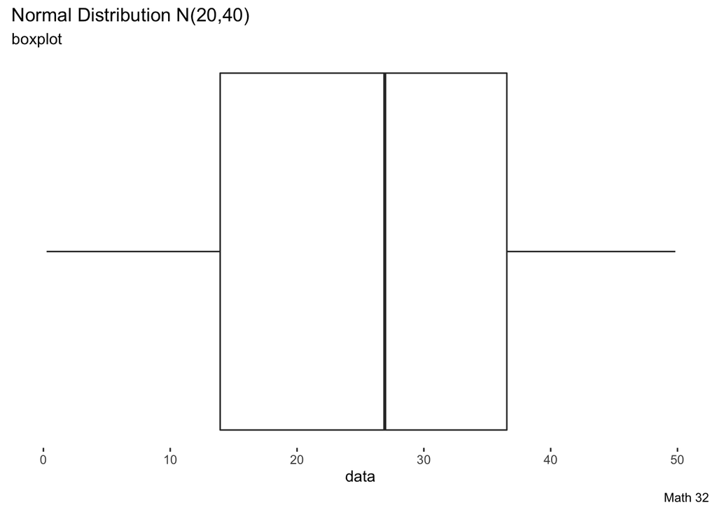

```r
N <- 1000
a <- 20
b <- 40
data <- rnorm(N, a, b)
df <- data.frame(data)

ggplot(df, aes(y = data)) +
  coord_flip() +
  geom_boxplot() +
  labs(title = paste0("Normal Distribution N(", a, ",", b, ")"),
       subtitle = "boxplot",
       caption = "Math 32") +
  theme(axis.text.y = element_blank(),
        axis.ticks.y = element_blank(),
        panel.background = element_blank(),
        panel.grid.major = element_blank(),
        panel.grid.minor = element_blank()) +
  ylim(0,50)
```

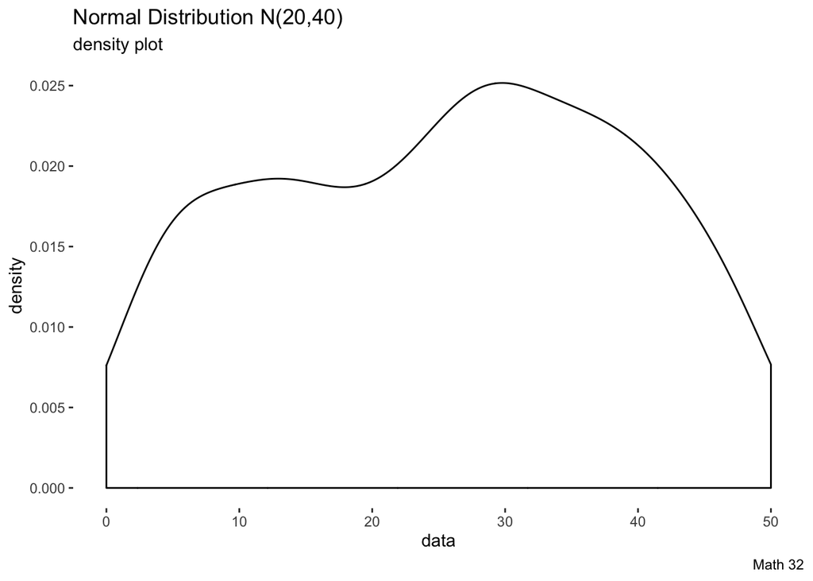

```r
ggplot(df, aes(x = data)) +
  geom_density() +
  labs(title = paste0("Normal Distribution N(", a, ",", b, ")"),
       subtitle = "density plot",
       caption = "Math 32") +
  theme(panel.background = element_blank(),
        panel.grid.major = element_blank(),
        panel.grid.minor = element_blank()) +
  xlim(0,50)
```

7. Make at least two observations about the results (the graphs) in an unordered list.

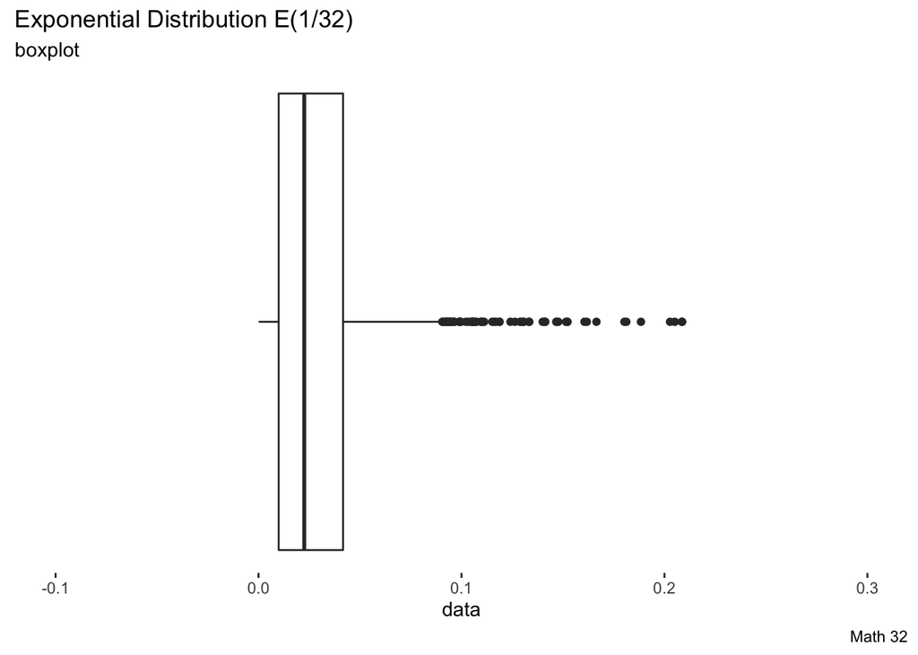

```r
N <- 1000
mu <- 32
data <- rexp(N,mu)
df <- data.frame(data)

ggplot(df, aes(y = data)) +
  coord_flip() +
  geom_boxplot() +
  labs(title = paste0("Exponential Distribution E(1/", mu, ")"),
       subtitle = "boxplot",
       caption = "Math 32") +
  theme(axis.text.y = element_blank(),
        axis.ticks.y = element_blank(),
        panel.background = element_blank(),
        panel.grid.major = element_blank(),
        panel.grid.minor = element_blank()) +
  ylim(-.1,.3)
```

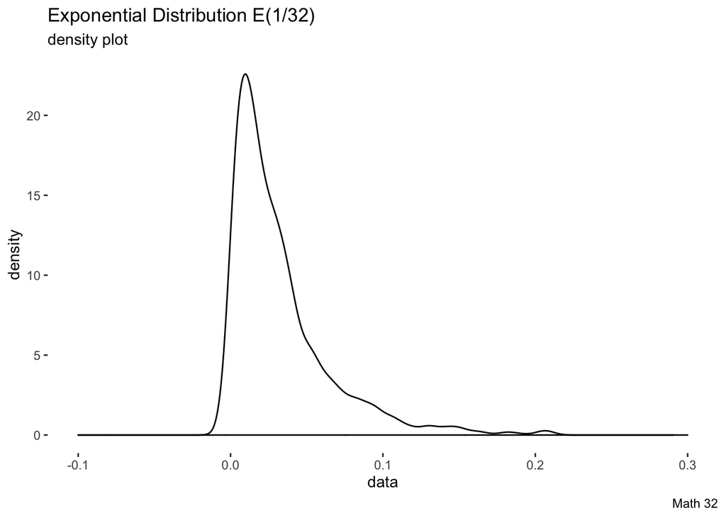

```r
ggplot(df, aes(x = data)) +
  geom_density() +
  labs(title = paste0("Exponential Distribution E(1/", mu, ")"),
       subtitle = "density plot",
       caption = "Math 32") +
  theme(panel.background = element_blank(),
        panel.grid.major = element_blank(),
        panel.grid.minor = element_blank()) +
  xlim(-.1,.3)
```

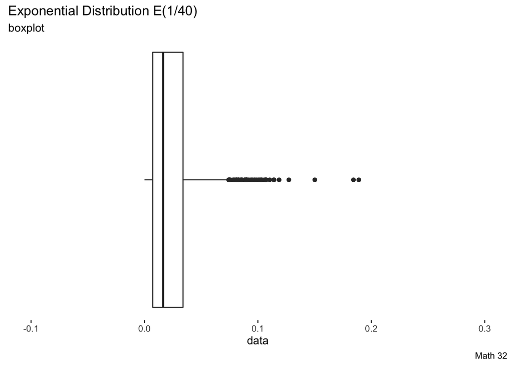

```r
N <- 1000
mu <- 40
data <- rexp(N,mu)
df <- data.frame(data)

ggplot(df, aes(y = data)) +
  coord_flip() +
  geom_boxplot() +
  labs(title = paste0("Exponential Distribution E(1/", mu, ")"),
       subtitle = "boxplot",
       caption = "Math 32") +
  theme(axis.text.y = element_blank(),
        axis.ticks.y = element_blank(),
        panel.background = element_blank(),
        panel.grid.major = element_blank(),
        panel.grid.minor = element_blank()) +
  ylim(-.1,.3)
```

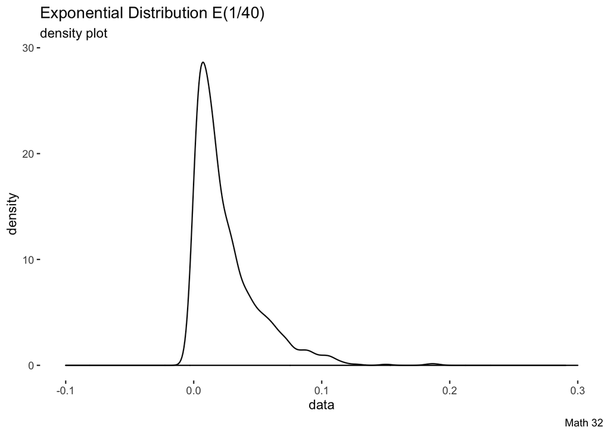

```r
ggplot(df, aes(x = data)) +
  geom_density() +
  labs(title = paste0("Exponential Distribution E(1/", mu, ")"),
       subtitle = "density plot",
       caption = "Math 32") +
  theme(panel.background = element_blank(),
        panel.grid.major = element_blank(),
        panel.grid.minor = element_blank()) +
  xlim(-.1,.3)
```

10. Make at least two observations about the results (the graphs) in an unordered list.

- increasing mu makes the max data values smaller
- increasing mu makes the max density larger
11. Verify that you have 12 graphs in total (6 boxplots and 6 density plots), and replace “Math 32” with your full name in all of the graphs.
12. Finally, `knit` your work as either an HTML or PDF document, and upload that document back into the CatCourses assignment.